# Copy_of_0_67143600_1782630796

Part – A

Problem 10: Comparing Small and Large Neural Networks

In this exercise, you will compare the performance of small and large neural networks. First, create a small neural network with one hidden layer and two neurons. Run the model and record the test loss. Next, create a larger network with three hidden layers and five neurons in each layer. Run the model and observe the test loss and convergence speed. Compare both models and explain whether increasing the network size improves performance and learning speed.

Part – B : Program - 1

A.Design a single unit perceptron for classification of a linearly separable binary dataset without using pre-defined models. Use the Perceptron() from sklearn.

B.Identify the problem with single unit Perceptron. Classify using Or-, And- and Xor-ed data and analyze the result.

```
Weights: [[1218.5 -193. ]]
Bias: [-7.]
Accuracy: 0.51
```

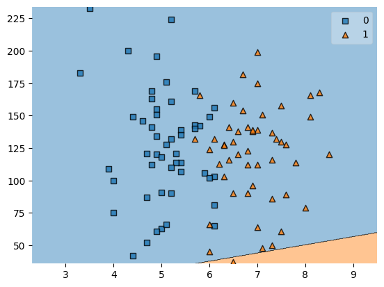

[output not shown]

[figure not shown]

```python
# PGM 1 [A]
import pandas as pd
from sklearn.linear_model import Perceptron
from mlxtend.plotting import plot_decision_regions
import matplotlib.pyplot as plt

df = pd.read_csv('/content/placement-dataset.csv')

X = df[['cgpa', 'iq']]
y = df['placement']

model = Perceptron()
model.fit(X, y)

print("Weights:", model.coef_)
print("Bias:", model.intercept_)

print("Accuracy:", model.score(X, y))

plot_decision_regions(X.values, y.values, clf=model, legend=1)
plt.show()
```

```
AND Weights: [[2. 2.]]
AND Bias: [-2.]
OR Weights: [[2. 2.]]
OR Bias: [-1.]
XOR Weights: [[0. 0.]]
XOR Bias: [0.]
```

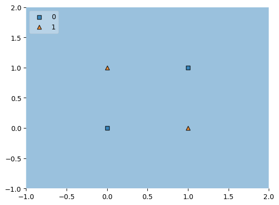

```python
#PGM 1 [B]
import pandas as pd
import matplotlib.pyplot as plt
from sklearn.linear_model import Perceptron
from mlxtend.plotting import plot_decision_regions

def train_and_print(data, name):
    X = data[['input1', 'input2']]
    y = data['output']

    model = Perceptron()
    model.fit(X, y)

    print(f"{name} Weights:", model.coef_)
    print(f"{name} Bias:", model.intercept_)

    return model, X, y

data = {
    "AND": pd.DataFrame({'input1':[1,1,0,0],'input2':[1,0,1,0],'output':[1,0,0,0]}),
    "OR":  pd.DataFrame({'input1':[1,1,0,0],'input2':[1,0,1,0],'output':[1,1,1,0]}),
    "XOR": pd.DataFrame({'input1':[1,1,0,0],'input2':[1,0,1,0],'output':[0,1,1,0]})
}

models = {}
for name, df in data.items():
    models[name] = train_and_print(df, name)

model, X, y = models["XOR"]
plot_decision_regions(X.values, y.values, clf=model, legend=2)
plt.show()
```

Part – A

Problem 9: Designing the Smallest Effective Neural Network

In this exercise, your goal is to design the smallest neural network that achieves a test loss of 0.177 or lower. You may change the number of hidden layers, number of neurons, and activation functions. Run multiple experiments and record the test loss for each configuration. Identify the smallest architecture that achieves the required performance and explain your findings.

Part – B:

Program - 02

Build an Artificial Neural Network by implementing the Backpropagation algorithm and test the same using appropriate data sets. Vary the activation functions used and compare the results.

```python
# PGM 2
from keras.models import Sequential
from keras.layers import Dense
from sklearn.datasets import load_iris
from sklearn.model_selection import train_test_split
from keras.utils import to_categorical

# Load data
X, y = load_iris(return_X_y=True)
y = to_categorical(y, 3)

X_train, X_test, y_train, y_test = train_test_split(X, y, test_size=0.4)

def run_model(act):
    print(f"\n=== {act.upper()} ===")

    model = Sequential([
        Dense(4, activation=act, input_shape=(4,)),
        Dense(3, activation='softmax')
    ])

    model.compile(optimizer='sgd',
                  loss='categorical_crossentropy',
                  metrics=['accuracy'])

    model.summary()  # like screenshot

    model.fit(X_train, y_train, epochs=5, verbose=0)

    loss, acc = model.evaluate(X_test, y_test, verbose=0)
    print(f"Loss: {loss:.3f}")
    print(f"Accuracy: {acc:.3f}")

# Run for 3 activations
for act in ['sigmoid', 'relu', 'tanh']:
    run_model(act)
```

```
=== SIGMOID ===
```

```
Model: "sequential_6"
```

```
┏━━━━━━━━━━━━━━━━━━━━━━━━━━━━━━━━━┳━━━━━━━━━━━━━━━━━━━━━━━━┳━━━━━━━━━━━━━━━┓
┃ Layer (type)                    ┃ Output Shape           ┃       Param # ┃
┡━━━━━━━━━━━━━━━━━━━━━━━━━━━━━━━━━╇━━━━━━━━━━━━━━━━━━━━━━━━╇━━━━━━━━━━━━━━━┩
│ dense_12 (Dense)                │ (None, 4)              │            20 │
├─────────────────────────────────┼────────────────────────┼───────────────┤
│ dense_13 (Dense)                │ (None, 3)              │            15 │
└─────────────────────────────────┴────────────────────────┴───────────────┘
```

```
 Total params: 35 (140.00 B)
```

```
 Trainable params: 35 (140.00 B)
```

```
 Non-trainable params: 0 (0.00 B)
```

```
Loss: 1.732
Accuracy: 0.300

=== RELU ===
```

```
Model: "sequential_7"
```

```
┏━━━━━━━━━━━━━━━━━━━━━━━━━━━━━━━━━┳━━━━━━━━━━━━━━━━━━━━━━━━┳━━━━━━━━━━━━━━━┓
┃ Layer (type)                    ┃ Output Shape           ┃       Param # ┃
┡━━━━━━━━━━━━━━━━━━━━━━━━━━━━━━━━━╇━━━━━━━━━━━━━━━━━━━━━━━━╇━━━━━━━━━━━━━━━┩
│ dense_14 (Dense)                │ (None, 4)              │            20 │
├─────────────────────────────────┼────────────────────────┼───────────────┤
│ dense_15 (Dense)                │ (None, 3)              │            15 │
└─────────────────────────────────┴────────────────────────┴───────────────┘
```

```
 Total params: 35 (140.00 B)
```

```
 Trainable params: 35 (140.00 B)
```

```
 Non-trainable params: 0 (0.00 B)
```

```
Loss: 0.964
Accuracy: 0.700

=== TANH ===
```

```
Model: "sequential_8"
```

```
┏━━━━━━━━━━━━━━━━━━━━━━━━━━━━━━━━━┳━━━━━━━━━━━━━━━━━━━━━━━━┳━━━━━━━━━━━━━━━┓
┃ Layer (type)                    ┃ Output Shape           ┃       Param # ┃
┡━━━━━━━━━━━━━━━━━━━━━━━━━━━━━━━━━╇━━━━━━━━━━━━━━━━━━━━━━━━╇━━━━━━━━━━━━━━━┩
│ dense_16 (Dense)                │ (None, 4)              │            20 │
├─────────────────────────────────┼────────────────────────┼───────────────┤
│ dense_17 (Dense)                │ (None, 3)              │            15 │
└─────────────────────────────────┴────────────────────────┴───────────────┘
```

```
 Total params: 35 (140.00 B)
```

```
 Trainable params: 35 (140.00 B)
```

```
 Non-trainable params: 0 (0.00 B)
```

```
Loss: 1.145
Accuracy: 0.300
```

Part – A

Problem 8: Effect of Regularization

In this exercise, you will study the effect of regularization in preventing overfitting. Use one hidden layer with three neurons and ReLU activation. First, run the model without regularization and record the test loss. Then apply regularization values of 0.001, 0.01, and 0.1 and observe the results. Compare the performance and explain whether regularization improves the model.

Part – B :

Program - 03

Build a Deep Feed Forward ANN by implementing the Backpropagation algorithm and test the same using appropriate data sets. Use the number of hidden layers >=4.

```python
# PGM 3
from keras.models import Sequential
from keras.layers import Dense, Activation
from sklearn.datasets import load_iris
from sklearn.model_selection import train_test_split

# Load data
X, y = load_iris(return_X_y=True)

X_train, X_test, y_train, y_test = train_test_split(X, y, test_size=0.4)

# Build model
model = Sequential()

# Repeat pattern 3 times (2 → 1 neurons)
for i in range(3):
    if i == 0:
        model.add(Dense(2, input_shape=(4,)))
    else:
        model.add(Dense(2))
    model.add(Activation('sigmoid'))

    model.add(Dense(1))
    model.add(Activation('sigmoid'))

# Compile
model.compile(loss='mean_squared_error', optimizer='sgd', metrics=['accuracy'])

# Output like your screenshot
model.summary()

# Train & evaluate
model.fit(X_train, y_train, epochs=5, verbose=0)
print(model.evaluate(X_test, y_test))
```

```
Model: "sequential_9"
```

```
┏━━━━━━━━━━━━━━━━━━━━━━━━━━━━━━━━━┳━━━━━━━━━━━━━━━━━━━━━━━━┳━━━━━━━━━━━━━━━┓
┃ Layer (type)                    ┃ Output Shape           ┃       Param # ┃
┡━━━━━━━━━━━━━━━━━━━━━━━━━━━━━━━━━╇━━━━━━━━━━━━━━━━━━━━━━━━╇━━━━━━━━━━━━━━━┩
│ dense_18 (Dense)                │ (None, 2)              │            10 │
├─────────────────────────────────┼────────────────────────┼───────────────┤
│ activation_2 (Activation)       │ (None, 2)              │             0 │
├─────────────────────────────────┼────────────────────────┼───────────────┤
│ dense_19 (Dense)                │ (None, 1)              │             3 │
├─────────────────────────────────┼────────────────────────┼───────────────┤
│ activation_3 (Activation)       │ (None, 1)              │             0 │
├─────────────────────────────────┼────────────────────────┼───────────────┤
│ dense_20 (Dense)                │ (None, 2)              │             4 │
├─────────────────────────────────┼────────────────────────┼───────────────┤
│ activation_4 (Activation)       │ (None, 2)              │             0 │
├─────────────────────────────────┼────────────────────────┼───────────────┤
│ dense_21 (Dense)                │ (None, 1)              │             3 │
├─────────────────────────────────┼────────────────────────┼───────────────┤
│ activation_5 (Activation)       │ (None, 1)              │             0 │
├─────────────────────────────────┼────────────────────────┼───────────────┤
│ dense_22 (Dense)                │ (None, 2)              │             4 │
├─────────────────────────────────┼────────────────────────┼───────────────┤
│ activation_6 (Activation)       │ (None, 2)              │             0 │
├─────────────────────────────────┼────────────────────────┼───────────────┤
│ dense_23 (Dense)                │ (None, 1)              │             3 │
├─────────────────────────────────┼────────────────────────┼───────────────┤
│ activation_7 (Activation)       │ (None, 1)              │             0 │
└─────────────────────────────────┴────────────────────────┴───────────────┘
```

```
 Total params: 27 (108.00 B)
```

```
 Trainable params: 27 (108.00 B)
```

```
 Non-trainable params: 0 (0.00 B)
```

```
2/2 ━━━━━━━━━━━━━━━━━━━━ 1s 68ms/step - accuracy: 0.2500 - loss: 0.9266
[0.9266488552093506, 0.25]
```

Part – A

Problem 7: Effect of Learning Rate on Model Performance

In this exercise, you will study how the learning rate affects training. Use one hidden layer with three neurons and ReLU activation. First, set the learning rate to 0.001 and run the model. Record the test loss. Then increase the learning rate to 0.01, 0.03, and 0.1, running the model each time. Compare the test loss values and identify which learning rate provides the best performance. Explain why very high learning rates may reduce model performance.

Part – B:

Program-04

Design and implement an Image classification model to classify a dataset of images using Deep Feed Forward NN. Record the accuracy corresponding to the number of epochs. Use the MNIST, CIFAR-10 datasets.

```
Downloading data from https://storage.googleapis.com/tensorflow/tf-keras-datasets/mnist.npz
11490434/11490434 ━━━━━━━━━━━━━━━━━━━━ 0s 0us/step
Shape of X_train: (60000, 28, 28)
Shape of y_train: (60000,)
Shape of X_test: (10000, 28, 28)
Shape of y_test: (10000,)
```

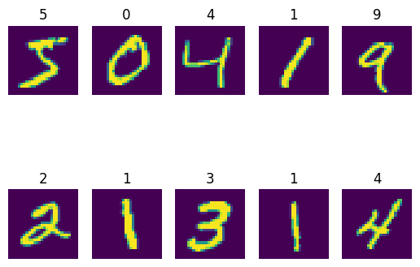

```
New shape of X_train: (60000, 784)
New shape of X_test: (10000, 784)

Model Summary
```

```
Model: "sequential_10"
```

```
┏━━━━━━━━━━━━━━━━━━━━━━━━━━━━━━━━━┳━━━━━━━━━━━━━━━━━━━━━━━━┳━━━━━━━━━━━━━━━┓
┃ Layer (type)                    ┃ Output Shape           ┃       Param # ┃
┡━━━━━━━━━━━━━━━━━━━━━━━━━━━━━━━━━╇━━━━━━━━━━━━━━━━━━━━━━━━╇━━━━━━━━━━━━━━━┩
│ dense_24 (Dense)                │ (None, 128)            │       100,480 │
├─────────────────────────────────┼────────────────────────┼───────────────┤
│ dense_25 (Dense)                │ (None, 64)             │         8,256 │
├─────────────────────────────────┼────────────────────────┼───────────────┤
│ dense_26 (Dense)                │ (None, 10)             │           650 │
└─────────────────────────────────┴────────────────────────┴───────────────┘
```

```
 Total params: 328,160 (1.25 MB)
```

```
 Trainable params: 109,386 (427.29 KB)
```

```
 Non-trainable params: 0 (0.00 B)
```

```
 Optimizer params: 218,774 (854.59 KB)
```

```
Training Data Evaluation
              precision    recall  f1-score   support

           0       1.00      0.99      1.00      5923
           1       0.99      0.99      0.99      6742
           2       0.99      0.99      0.99      5958
           3       0.99      0.99      0.99      6131
           4       0.99      0.99      0.99      5842
           5       0.99      0.99      0.99      5421
           6       0.99      0.99      0.99      5918
           7       0.99      0.99      0.99      6265
           8       0.99      0.98      0.98      5851
           9       0.99      0.99      0.99      5949

    accuracy                           0.99     60000
   macro avg       0.99      0.99      0.99     60000
weighted avg       0.99      0.99      0.99     60000


Test Data Evaluation
              precision    recall  f1-score   support

           0       0.99      0.98      0.99       980
           1       0.99      0.99      0.99      1135
           2       0.97      0.99      0.98      1032
           3       0.96      0.98      0.97      1010
           4       0.98      0.98      0.98       982
           5       0.98      0.97      0.97       892
           6       0.99      0.98      0.98       958
           7       0.97      0.98      0.97      1028
           8       0.98      0.96      0.97       974
           9       0.98      0.97      0.97      1009

    accuracy                           0.98     10000
   macro avg       0.98      0.98      0.98     10000
weighted avg       0.98      0.98      0.98     10000
```

```python
# PPGM 4
import tensorflow as tf
from tensorflow.keras import Sequential
from tensorflow.keras.layers import Dense, Input
from tensorflow.keras.datasets import mnist
from sklearn.metrics import classification_report
import matplotlib.pyplot as plt
import numpy as np

# Load data
(X_train, y_train), (X_test, y_test) = mnist.load_data()

# Shapes
print("Shape of X_train:", X_train.shape)
print("Shape of y_train:", y_train.shape)
print("Shape of X_test:", X_test.shape)
print("Shape of y_test:", y_test.shape)

# Show 10 images
for i in range(10):
    plt.subplot(2, 5, i+1)
    plt.imshow(X_train[i])
    plt.title(y_train[i])
    plt.axis('off')
plt.show()

# Preprocess
X_train = X_train.reshape(-1, 784) / 255
X_test = X_test.reshape(-1, 784) / 255

print("New shape of X_train:", X_train.shape)
print("New shape of X_test:", X_test.shape)

# Model
model = Sequential([
    Input(shape=(784,)),
    Dense(128, activation='relu'),
    Dense(64, activation='relu'),
    Dense(10, activation='softmax')
])

model.compile(optimizer='adam',
              loss='sparse_categorical_crossentropy',
              metrics=['accuracy'])

# Train
model.fit(X_train, y_train, epochs=5, batch_size=10, verbose=0)

# Predict
train_pred = np.argmax(model.predict(X_train, verbose=0), axis=1)
test_pred = np.argmax(model.predict(X_test, verbose=0), axis=1)

# Output
print("\nModel Summary")
model.summary()

print("\nTraining Data Evaluation")
print(classification_report(y_train, train_pred))

print("\nTest Data Evaluation")
print(classification_report(y_test, test_pred))
```

Part – A Problem 6: Studying Model Stability

In this exercise, you will analyze how stable the neural network is across multiple runs. Use a network with two hidden layers and three neurons in each layer with ReLU activation. Run the model and record the test loss. Repeat the experiment five times and record the test loss each time. Observe whether the test loss remains the same or changes. Explain why neural networks produce slightly different results in different runs.

Part – B :

Program - 05

Design and implement a CNN model (with 2 layers of convolutions) to classify multi category image datasets. Record the accuracy corresponding to the number of epochs. Use the MNIST, CIFAR-10 datasets.

```
Test loss 0.03626378998160362
Test accuracy 0.9894000291824341
7
```

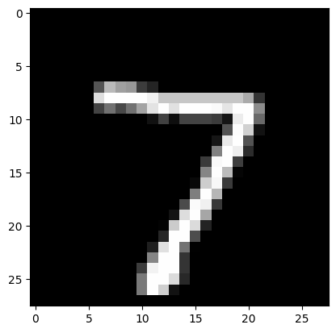

```python
# PGM 5
from tensorflow.keras import Sequential
from tensorflow.keras.layers import Conv2D, MaxPooling2D, Flatten, Dense
from tensorflow.keras.datasets import mnist
from tensorflow.keras.utils import to_categorical
import numpy as np
import matplotlib.pyplot as plt

# Load data
(train_X, train_Y), (test_X, test_Y) = mnist.load_data()

# Preprocess
train_X = train_X.reshape(-1, 28, 28, 1) / 255
test_X = test_X.reshape(-1, 28, 28, 1) / 255
train_Y = to_categorical(train_Y)
test_Y = to_categorical(test_Y)

# Model
model = Sequential([
    Conv2D(64, (3,3), activation='relu', input_shape=(28,28,1)),
    MaxPooling2D(2,2),
    Conv2D(64, (3,3), activation='relu'),
    MaxPooling2D(2,2),
    Flatten(),
    Dense(64, activation='relu'),
    Dense(10, activation='softmax')
])

model.compile(optimizer='adam',
              loss='categorical_crossentropy',
              metrics=['accuracy'])

# Train
model.fit(train_X, train_Y, epochs=10, batch_size=64, verbose=0)

# Evaluate
loss, acc = model.evaluate(test_X, test_Y, verbose=0)
print("Test loss", loss)
print("Test accuracy", acc)

# Prediction + display
pred = np.argmax(model.predict(test_X, verbose=0)[0])
print(pred)

plt.imshow(test_X[0].reshape(28,28), cmap='gray')
plt.show()
```

Part – A

Problem 6: Studying Model Stability

In this exercise, you will analyze how stable the neural network is across multiple runs. Use a network with two hidden layers and three neurons in each layer with ReLU activation. Run the model and record the test loss. Repeat the experiment five times and record the test loss each time. Observe whether the test loss remains the same or changes. Explain why neural networks produce slightly different results in different runs.

Part – B :

Program - 06

```
Downloading data from https://storage.googleapis.com/tensorflow/tf-keras-datasets/train-labels-idx1-ubyte.gz
29515/29515 ━━━━━━━━━━━━━━━━━━━━ 0s 0us/step
Downloading data from https://storage.googleapis.com/tensorflow/tf-keras-datasets/train-images-idx3-ubyte.gz
26421880/26421880 ━━━━━━━━━━━━━━━━━━━━ 0s 0us/step
Downloading data from https://storage.googleapis.com/tensorflow/tf-keras-datasets/t10k-labels-idx1-ubyte.gz
5148/5148 ━━━━━━━━━━━━━━━━━━━━ 0s 0us/step
Downloading data from https://storage.googleapis.com/tensorflow/tf-keras-datasets/t10k-images-idx3-ubyte.gz
4422102/4422102 ━━━━━━━━━━━━━━━━━━━━ 0s 0us/step
Test loss 0.29792165756225586
Test accuracy 0.8895999789237976
9
```

```python
# PGM 6
from tensorflow.keras import Sequential
from tensorflow.keras.layers import Conv2D, MaxPooling2D, Flatten, Dense
from tensorflow.keras.datasets import fashion_mnist
from tensorflow.keras.utils import to_categorical
import numpy as np
import matplotlib.pyplot as plt

# Load data
(train_X, train_Y), (test_X, test_Y) = fashion_mnist.load_data()

# Preprocess
train_X = train_X.reshape(-1, 28, 28, 1) / 255
test_X = test_X.reshape(-1, 28, 28, 1) / 255
train_Y = to_categorical(train_Y)
test_Y = to_categorical(test_Y)

# Model (4+ layers)
model = Sequential([
    Conv2D(64, (3,3), activation='relu', input_shape=(28,28,1)),  # 1
    MaxPooling2D(2,2),                                            # 2
    Conv2D(32, (3,3), activation='relu'),                         # 3
    MaxPooling2D(2,2),                                            # 4
    Flatten(),
    Dense(64, activation='relu'),
    Dense(10, activation='softmax')
])

# Compile
model.compile(optimizer='adam',
              loss='categorical_crossentropy',
              metrics=['accuracy'])

# Train
model.fit(train_X, train_Y, epochs=5, batch_size=64, verbose=0)

# Evaluate
loss, acc = model.evaluate(test_X, test_Y, verbose=0)
print("Test loss", loss)
print("Test accuracy", acc)

# Prediction
pred = np.argmax(model.predict(test_X, verbose=0)[0])
print(pred)

# Display image
plt.imshow(test_X[0].reshape(28,28), cmap='gray')
plt.show()
```

[output not shown]

Part – A

Problem 4: Effect of Increasing the Number of Hidden Layers

In this exercise, you will explore how adding more hidden layers affects the model. First, use one hidden layer with three neurons and run the model. Record the test loss. Next, add a second hidden layer with three neurons and observe the performance. Then add a third hidden layer with two neurons and run the model again. Compare all configurations and explain whether increasing the depth of the network improves model performance.

Part – B :

Program - 07

Design and implement a CNN model (with 2+ layers of convolutions) to classify multi category image datasets. Use the concept of padding and Batch Normalization while designing the CNN model. Record the accuracy corresponding the number of epochs. Use the Fashion MNIST/MNIST/CIFAR10 datasets.

```
Test loss 0.2744312584400177
Test accuracy 0.9003999829292297
9
```

```python
# PGM 7
from tensorflow.keras import Sequential
from tensorflow.keras.layers import Conv2D, MaxPooling2D, Flatten, Dense, BatchNormalization
from tensorflow.keras.datasets import fashion_mnist
from tensorflow.keras.utils import to_categorical
import numpy as np
import matplotlib.pyplot as plt

# Load data
(train_X, train_Y), (test_X, test_Y) = fashion_mnist.load_data()

# Preprocess
train_X = train_X.reshape(-1, 28, 28, 1) / 255
test_X = test_X.reshape(-1, 28, 28, 1) / 255
train_Y = to_categorical(train_Y)
test_Y = to_categorical(test_Y)

# Model (4+ layers + BatchNorm + padding)
model = Sequential([
    Conv2D(64, (3,3), padding='same', activation='relu', input_shape=(28,28,1)),
    BatchNormalization(),
    MaxPooling2D(2,2, padding='same'),

    Conv2D(32, (3,3), padding='same', activation='relu'),
    BatchNormalization(),
    MaxPooling2D(2,2, padding='same'),

    Conv2D(16, (3,3), padding='same', activation='relu'),
    MaxPooling2D(2,2, padding='same'),

    Flatten(),
    Dense(64, activation='relu'),
    Dense(10, activation='softmax')
])

# Compile
model.compile(optimizer='adam',
              loss='categorical_crossentropy',
              metrics=['accuracy'])

# Train
model.fit(train_X, train_Y, epochs=5, batch_size=64, verbose=0)

# Evaluate
loss, acc = model.evaluate(test_X, test_Y, verbose=0)
print("Test loss", loss)
print("Test accuracy", acc)

# Prediction
pred = np.argmax(model.predict(test_X, verbose=0)[0])
print(pred)

# Show image
plt.imshow(test_X[0].reshape(28,28), cmap='gray')
plt.show()
```

[output not shown]

Part - A

Problem 2: Effect of Increasing the Number of Hidden Neurons

In this exercise, you will study how increasing the number of neurons improves the learning capability of the neural network. Start with one hidden layer containing only one neuron and use ReLU activation. Run the model and record the test loss. Then increase the number of neurons to two and run the model again. Next, increase the number to three neurons and observe the change in model performance. Compare all results and explain how increasing the number of neurons affects the model's ability to learn complex patterns.

Part – B

Program - 09

Use the concept of Data Augmentation to increase the data size from a single image.

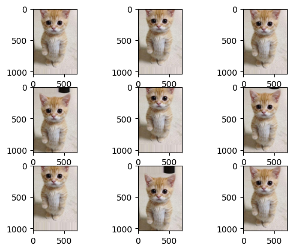

```python
# PGM 9
from numpy import expand_dims
from tensorflow.keras.preprocessing import image
from tensorflow.keras.preprocessing.image import ImageDataGenerator
from matplotlib import pyplot

# load image
img = image.load_img('cat.png')

# convert to array
data = image.img_to_array(img)

# expand dims
samples = expand_dims(data, 0)

# augmentation
datagen = ImageDataGenerator(width_shift_range=0.2)

# iterator
it = datagen.flow(samples, batch_size=1)

# generate images
for i in range(9):
    pyplot.subplot(330 + 1 + i)
    batch = next(it)
    pyplot.imshow(batch[0].astype('uint8'))

pyplot.show()
```

Part – A

Problem 1: Understanding Linear and Nonlinear Models

In this exercise, you will investigate whether a simple neural network can learn nonlinear relationships between input features. The model currently has no hidden layer and uses a Linear activation function. Observe the dataset and predict whether the model will be able to learn nonlinear patterns. Run the model and record the training loss and test loss. Next, add one hidden layer with one neuron and keep the activation as Linear. Run the model again and observe the loss values. Finally, change the activation function to ReLU and run the model. Compare the results and explain whether the nonlinear activation helps the model learn nonlinearities effectively.

Part - B:

Program - 10

Implement RNN for sentiment analysis on movie reviews.

```python
# PGM 10
from tensorflow.keras.datasets import imdb
from tensorflow.keras.preprocessing.sequence import pad_sequences
from tensorflow.keras.models import Sequential
from tensorflow.keras.layers import Embedding, SimpleRNN, Dense

# Load data (top 10k words)
(X_train, y_train), (X_test, y_test) = imdb.load_data(num_words=10000)

# Pad sequences
X_train = pad_sequences(X_train, maxlen=50)
X_test = pad_sequences(X_test, maxlen=50)

print("Train shape:", X_train.shape)

# Model
model = Sequential([
    Embedding(10000, 32, input_length=50),
    SimpleRNN(32),
    Dense(1, activation='sigmoid')
])

# Show summary (like screenshot)
model.summary()

# Compile
model.compile(optimizer='adam',
              loss='binary_crossentropy',
              metrics=['accuracy'])

# Train
model.fit(X_train, y_train, epochs=5, batch_size=64, verbose=0)

# Evaluate`
loss, acc = model.evaluate(X_test, y_test, verbose=0)
print("Test loss:", loss)
print("Test accuracy:", acc)
```

```
Downloading data from https://storage.googleapis.com/tensorflow/tf-keras-datasets/imdb.npz
17464789/17464789 ━━━━━━━━━━━━━━━━━━━━ 0s 0us/step
Train shape: (25000, 50)
```

```
Model: "sequential"
```

```
┏━━━━━━━━━━━━━━━━━━━━━━━━━━━━━━━━━┳━━━━━━━━━━━━━━━━━━━━━━━━┳━━━━━━━━━━━━━━━┓
┃ Layer (type)                    ┃ Output Shape           ┃       Param # ┃
┡━━━━━━━━━━━━━━━━━━━━━━━━━━━━━━━━━╇━━━━━━━━━━━━━━━━━━━━━━━━╇━━━━━━━━━━━━━━━┩
│ embedding (Embedding)           │ ?                      │   0 (unbuilt) │
├─────────────────────────────────┼────────────────────────┼───────────────┤
│ simple_rnn (SimpleRNN)          │ ?                      │   0 (unbuilt) │
├─────────────────────────────────┼────────────────────────┼───────────────┤
│ dense (Dense)                   │ ?                      │   0 (unbuilt) │
└─────────────────────────────────┴────────────────────────┴───────────────┘
```

```
 Total params: 0 (0.00 B)
```

```
 Trainable params: 0 (0.00 B)
```

```
 Non-trainable params: 0 (0.00 B)
```

```
Test loss: 0.7632827162742615
Test accuracy: 0.7714800238609314
```

Part – A

Problem 11: Understanding Linear and Nonlinear Models

In this exercise, you will investigate whether a simple neural network can learn nonlinear relationships between input features. The model currently has no hidden layer and uses a Linear activation function. Observe the dataset and predict whether the model will be able to learn nonlinear patterns. Run the model and record the training loss and test loss. Next, add one hidden layer with one neuron and keep the activation as Linear. Run the model again and observe the loss values. Finally, change the activation function to ReLU and run the model. Compare the results and explain whether the nonlinear activation helps the model learn nonlinearities effectively.

Part – B:

Program - 11

Implement Bidirectional LSTM for sentiment analysis on movie reviews.

```
Test loss: 0.5763993263244629
Test accuracy: 0.8523600101470947
[0.5000849366188049, 0.27845245599746704, 0.19899271428585052, 0.1574081927537918, 0.13413941860198975, 0.11146014928817749, 0.11265917122364044, 0.06602708995342255, 0.05878004431724548, 0.07877187430858612]
[0.7473599910736084, 0.8927599787712097, 0.927079975605011, 0.9435200095176697, 0.9525600075721741, 0.959879994392395, 0.9598399996757507, 0.9783200025558472, 0.981440007686615, 0.9731199741363525]
```

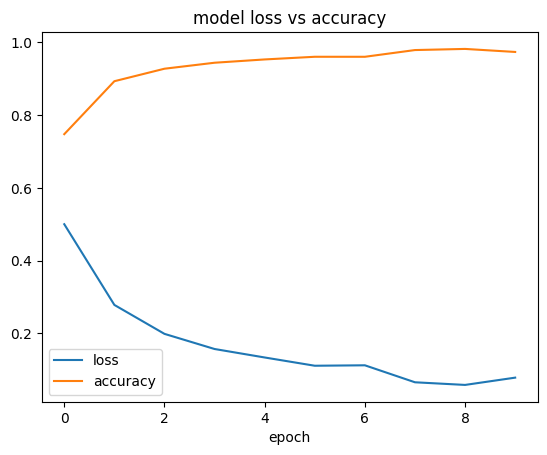

```python
#  PGM 11
import numpy as np
from tensorflow.keras.datasets import imdb
from tensorflow.keras.preprocessing.sequence import pad_sequences
from tensorflow.keras.models import Sequential
from tensorflow.keras.layers import Embedding, LSTM, Dense, Dropout, Bidirectional
import matplotlib.pyplot as plt

# Parameters
max_words = 10000
maxlen = 200

# Load + preprocess
(X_train, y_train), (X_test, y_test) = imdb.load_data(num_words=max_words)
X_train = pad_sequences(X_train, maxlen=maxlen)
X_test = pad_sequences(X_test, maxlen=maxlen)

# Model
model = Sequential([
    Embedding(max_words, 128, input_length=maxlen),
    Bidirectional(LSTM(64)),
    Dropout(0.5),
    Dense(1, activation='sigmoid')
])

# Compile
model.compile(optimizer='adam',
              loss='binary_crossentropy',
              metrics=['accuracy'])

# Train
history = model.fit(X_train, y_train, epochs=10, batch_size=128, verbose=0)

# Evaluate
loss, acc = model.evaluate(X_test, y_test, verbose=0)
print("Test loss:", loss)
print("Test accuracy:", acc)

# Print lists (like your screenshot)
print(history.history['loss'])
print(history.history['accuracy'])

# Plot
plt.plot(history.history['loss'])
plt.plot(history.history['accuracy'])
plt.title('model loss vs accuracy')
plt.xlabel('epoch')
plt.legend(['loss', 'accuracy'])
plt.show()
```